# CBM_Gear_Failure_draft

```python
# Common imports
import os
import pandas as pd
import numpy as np
from sklearn import preprocessing
import seaborn as sns
sns.set(color_codes=True)
import matplotlib.pyplot as plt
%matplotlib inline

from numpy.random import seed
from tensorflow import set_random_seed

from keras.layers import Input, Dropout
from keras.layers.core import Dense
from keras.models import Model, Sequential, load_model
from keras import regularizers
from keras.models import model_from_json
```

See Readme Document for IMS Bearing Data for further information on the experiment and available data.

Each data set consists of individual files that are 1-second vibration signal snapshots recorded at specific intervals. Each file consists of 20,480 points with the sampling rate set at 20 kHz. The file name indicates when the data was collected. Each record (row) in the data file is a data point. Data collection was facilitated by NI DAQ Card 6062E. Larger intervals of time stamps (showed in file names) indicate resumption of the experiment in the next working day.

Assumption is that gear degradation occur gradually over time, so use one datapoint every 10 minutes in the following analysis. Each 10 minute datapoint is aggregated by using the mean absolute value of the vibration recordings over the 20480 datapoints in each file. We then merge together everything in a single dataframe.

In the following analysis, I use the data from the 2nd Gear failure test (see readme document for further info on that experiment).

```python
data_dir = '2nd_test'
merged_data = pd.DataFrame()

for filename in os.listdir(data_dir):
    print(filename)
    dataset=pd.read_csv(os.path.join(data_dir, filename), sep='\t')
    dataset_mean_abs = np.array(dataset.abs().mean())
    dataset_mean_abs = pd.DataFrame(dataset_mean_abs.reshape(1,4))
    dataset_mean_abs.index = [filename]

    merged_data = merged_data.append(dataset_mean_abs)

merged_data.columns = ['Bearing 1','Bearing 2','Bearing 3','Bearing 4']
```

[output not shown]

[output cut: 929 more lines]

[output not shown]

Convert index to datetime format (using the following convention: https://docs.python.org/3.4/library/datetime.html)

```python
merged_data.index = pd.to_datetime(merged_data.index, format='%Y.%m.%d.%H.%M.%S')
```

Sort dataframe by index in chronological order:

```python
merged_data = merged_data.sort_index()
```

Save merged dataset as csv:

```python
merged_data.to_csv('merged_dataset_BearingTest_2.csv')
```

```python
merged_data.head()
```

|  | Bearing 1 | Bearing 2 | Bearing 3 | Bearing 4 |
| --- | --- | --- | --- | --- |
| 2004-02-12 10:32:39 | 0.058333 | 0.071832 | 0.083242 | 0.043067 |
| 2004-02-12 10:42:39 | 0.058995 | 0.074006 | 0.084435 | 0.044541 |
| 2004-02-12 10:52:39 | 0.060236 | 0.074227 | 0.083926 | 0.044443 |
| 2004-02-12 11:02:39 | 0.061455 | 0.073844 | 0.084457 | 0.045081 |
| 2004-02-12 11:12:39 | 0.061361 | 0.075609 | 0.082837 | 0.045118 |

# Anomaly detection model:

Define train/test data. Perform a simple split where we train on the first part of the dataset, which should represent normal running conditions.

```python
dataset_train = merged_data['2004-02-12 11:02:39':'2004-02-13 23:52:39']
dataset_test = merged_data['2004-02-13 23:52:39':]
```

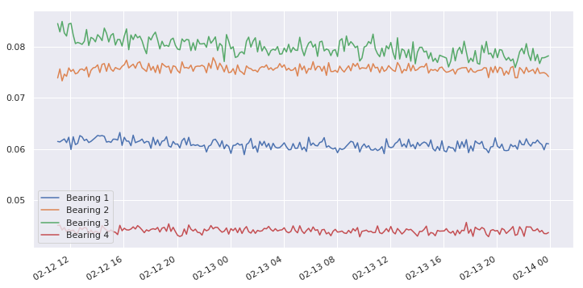

```python
dataset_train.plot(figsize = (12,6))
```

Normalize data:

```python
scaler = preprocessing.MinMaxScaler()

X_train = pd.DataFrame(scaler.fit_transform(dataset_train),
                              columns=dataset_train.columns,
                              index=dataset_train.index)
# Random shuffle training data
X_train.sample(frac=1)

X_test = pd.DataFrame(scaler.transform(dataset_test),
                             columns=dataset_test.columns,
                             index=dataset_test.index)
```

# PCA type model for anomaly detection:

```python
from sklearn.decomposition import PCA
```

As an initial attempt, lets compress the sensor readings from 4 input features down to the two main principal components.

```python
pca = PCA(n_components=2, svd_solver= 'full')
```

```python
X_train_PCA = pca.fit_transform(X_train)
X_train_PCA = pd.DataFrame(X_train_PCA)
X_train_PCA.index = X_train.index

X_test_PCA = pca.transform(X_test)
X_test_PCA = pd.DataFrame(X_test_PCA)
X_test_PCA.index = X_test.index
```

```python
pca.explained_variance_ratio_
```

```
array([0.51012041, 0.20459247])
```

# The Mehlanobis distance metric

The Mahalanobis distance is a measure of the distance between a point P and a distribution D. It is a multi-dimensional generalization of the idea of measuring how many standard deviations away P is from the mean of D. This distance is zero if P is at the mean of D, and grows as P moves away from the mean along each principal component axis. The Mahalanobis distance is thus unitless and scale-invariant, and takes into account the correlations of the data set. Mahalanobis distance is widely used in cluster analysis and classification techniques. It is closely related to Hotelling's T-square distribution used for multivariate statistical testing. In order to use the Mahalanobis distance to classify a test point as belonging to one of N classes, one first estimates the covariance matrix of each class, usually based on samples known to belong to each class. In our case, as we are only interested in classifying "normal" vs "anomaly", we use training data that only contains normal operating conditions to calculate the covariance matrix. Then, given a test sample, we compute the Mahalanobis distance to the "normal" class, and classifies the test point as an "anomaly" if the distance is above a certain threshold. Note of caution: Use of the Mahalanobis' distance implies that inference can be done through the mean and covariance matrix - and that is a property of the normal distribution alone. If you use the MD on your data, you are basically pretending that they are Normal. The square of the distances from the centroid should then follow a χ2 distribution (with d degrees of freedom equal to the number of dimensions/features). We can then calculate the probability that a new data point belongs to the set using its Mahalanobis distance. This criteria is likely not fulfilled in this case, as the input features are not normal distributed. However, we try anyway and see how well it works. https://en.wikipedia.org/wiki/Mahalanobis_distance

## Functions for calculating covariance matrices and the Mehlanobis distance metric

```python
def cov_matrix(data, verbose=False):
    covariance_matrix = np.cov(data, rowvar=False)
    if is_pos_def(covariance_matrix):
        inv_covariance_matrix = np.linalg.inv(covariance_matrix)
        if is_pos_def(inv_covariance_matrix):
            return covariance_matrix, inv_covariance_matrix
        else:
            print("Error: Inverse of Covariance Matrix is not positive definite!")
    else:
        print("Error: Covariance Matrix is not positive definite!")


def MahalanobisDist(inv_cov_matrix, mean_distr, data, verbose=False):
    inv_covariance_matrix = inv_cov_matrix
    vars_mean = mean_distr
    diff = data - vars_mean
    md = []
    for i in range(len(diff)):
        md.append(np.sqrt(diff[i].dot(inv_covariance_matrix).dot(diff[i])))
    return md


def MD_detectOutliers(dist, extreme=False, verbose=False):
    k = 3. if extreme else 2.
    threshold = np.mean(dist) * k
    outliers = []
    for i in range(len(dist)):
        if dist[i] >= threshold:
            outliers.append(i)  # index of the outlier
    return np.array(outliers)


def MD_threshold(dist, extreme=False, verbose=False):
    k = 3. if extreme else 2.
    threshold = np.mean(dist) * k
    return threshold


def is_pos_def(A):
    if np.allclose(A, A.T):
        try:
            np.linalg.cholesky(A)
            return True
        except np.linalg.LinAlgError:
            return False
    else:
        return False
```

Define train/test set from the principal components:

```python
data_train = np.array(X_train_PCA.values)
data_test = np.array(X_test_PCA.values)
```

Calculate the covariance matrix and its inverse, based on data in the training set.

```python
cov_matrix, inv_cov_matrix  = cov_matrix(data_train)
```

Also calculate the mean value for the input variables in the training set, as this is used later to calculate the Mahalanobis distance to datapoints in the test set

```python
mean_distr = data_train.mean(axis=0)
```

Using the covariance matrix and its inverse, we can now calculate the Mahalanobis distance for the datapoints in the training set, and find the threshold value to flag datapoint as an anomaly.

One can then calculate the Mahalanobis distance for the data in the test set, and compare that with the anomaly threshold given by the distribution of the data in the training set defining "normal conditions".

```python
dist_test = MahalanobisDist(inv_cov_matrix, mean_distr, data_test, verbose=False)
dist_train = MahalanobisDist(inv_cov_matrix, mean_distr, data_train, verbose=False)
threshold = MD_threshold(dist_train, extreme = True)
threshold
```

```
3.8120454918056765
```

## Threshold value for flagging an anomaly:

As mentioned previously,the square of the Mahalanobis distance to the centroid of the distribution should follow a χ2 distribution if the assumption of normal distributed input variables is fulfilled. This is also the assumtion behind the above calculation of the "threshold value" for flagging an anomaly. As this assumtion is likely not fulfilled in this case, it is beneficial to visualize the distribution of the Mahalanobis distance to set a good threshold value for flagging anomalies.

Start by visualizing the square of the Mahalanobis distance, which should then ideally follow a χ2 distribution.

```
(0.0, 15)
```

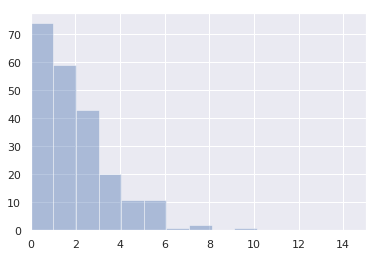

```python
plt.figure()
sns.distplot(np.square(dist_train),
             bins = 10,
             kde= False);
plt.xlim([0.0,15])
```

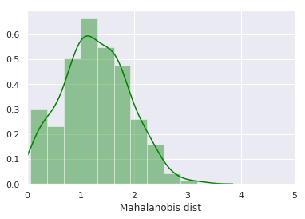

```python
plt.figure()
sns.distplot(dist_train,
             bins = 10,
             kde= True,
            color = 'green');
plt.xlim([0.0,5])
plt.xlabel('Mahalanobis dist')
plt.savefig('PCA_distr.jpg')
```

From the distribution, the above calculated threshold value of 3.8 seems quite resasonable, and is kept as the threshold for flagging anomalies.

Save the Mahalanobis distance, threshold and "anomaly flag" variable for the test data in a dataframe:

```python
anomaly = pd.DataFrame()
anomaly['Mob dist']= dist_test
anomaly['Thresh'] = threshold
# If Mob dist above threshold: Flag as anomaly
anomaly['Anomaly'] = anomaly['Mob dist'] > anomaly['Thresh']
anomaly.index = X_test_PCA.index
anomaly.head()
```

|  | Mob dist | Thresh | Anomaly |
| --- | --- | --- | --- |
| 2004-02-13 23:52:39 | 1.032676 | 3.812045 | False |
| 2004-02-14 00:02:39 | 1.148163 | 3.812045 | False |
| 2004-02-14 00:12:39 | 1.509998 | 3.812045 | False |
| 2004-02-14 00:22:39 | 1.849725 | 3.812045 | False |
| 2004-02-14 00:32:39 | 0.701075 | 3.812045 | False |

Save the Mahalanobis distance, threshold and "anomaly flag" variable for the training data in a dataframe:

```python
anomaly_train = pd.DataFrame()
anomaly_train['Mob dist']= dist_train
anomaly_train['Thresh'] = threshold
# If Mob dist above threshold: Flag as anomaly
anomaly_train['Anomaly'] = anomaly_train['Mob dist'] > anomaly_train['Thresh']
anomaly_train.index = X_train_PCA.index
anomaly_train.head()
```

|  | Mob dist | Thresh | Anomaly |
| --- | --- | --- | --- |
| 2004-02-12 11:02:39 | 1.667002 | 3.812045 | False |
| 2004-02-12 11:12:39 | 1.699415 | 3.812045 | False |
| 2004-02-12 11:22:39 | 2.671968 | 3.812045 | False |
| 2004-02-12 11:32:39 | 1.424617 | 3.812045 | False |
| 2004-02-12 11:42:39 | 1.624601 | 3.812045 | False |

Merge data in a single dataframe and save it as a csv file

```python
anomaly_alldata = pd.concat([anomaly_train, anomaly])
```

```python
anomaly_alldata.to_csv('Anomaly_distance.csv')
```

Based on the calculated statistics, any distance above the threshold will be flagged as an anomaly.

# verifying PCA model on test data:

Can then plot the calculated anomaly metric (Mob dist), and see at what point it crosses the anomaly threshold. (note the logarithmic y-axis).

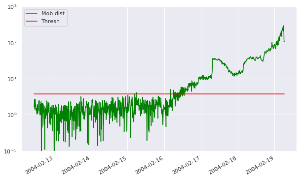

```python
anomaly_alldata.plot(logy=True, figsize = (10,6), ylim = [1e-1,1e3], color = ['green','red'])
```

# Other approach: Autoencoder model for anomaly detection

The basic idea is to use the Autoencoder network to "compress" the sensor readings to a low dimensional representation, which captures the correlations and interactions between the various variables. (Essentially the same principle as the PCA model, but here we also allow for non-linearities among the input features).

The autoencoder network is then trained on data representing "normal" operating conditions, with the goal of first compressing and then reconstructing the input variables. During the dimensionality reduction, the network learns the interactions between the various variables and should be able to re-construct them back to the original variables at the output. The idea is that as the monitored equipment degrades, or some anomalies occur, that should affect the interaction between the input variables. (e.g. changes in temperatures, pressures etc.). As this happens, one will start to see an increased error in the networks re-construction of the input variables. By monitoring the re-construction error, one can thus get an indication of the "health" of the monitored equipment as this error will increase as the equipment degrades.

As a result from the PCA analysis, we compressed the 4 input features down to the two main principal components. For the PCA model and Autoencoder to be comparable, I keep the same dimensionality here as well (2 dimensions in the bottleneck-layer of the network). In defining the network, I first project the input features to a higher dimensional space, then down to 2, reconstruct the high dimensional space again, and then back to an output layer of the same dimension as the input.

## Defining the Autoencoder network:

```python
seed(10)
set_random_seed(10)
act_func = 'elu'

# Input layer:
model=Sequential()
# First hidden layer, connected to input vector X.
model.add(Dense(10,activation=act_func,
                kernel_initializer='glorot_uniform',
                kernel_regularizer=regularizers.l2(0.0),
                input_shape=(X_train.shape[1],)
               )
         )

model.add(Dense(2,activation=act_func,
                kernel_initializer='glorot_uniform'))

model.add(Dense(10,activation=act_func,
                kernel_initializer='glorot_uniform'))

model.add(Dense(X_train.shape[1],
                kernel_initializer='glorot_uniform'))

model.compile(loss='mse',optimizer='adam')

# Train model for 100 epochs, batch size of 500:
NUM_EPOCHS=100
BATCH_SIZE=10
```

```python
history=model.fit(np.array(X_train),np.array(X_train),
                  batch_size=BATCH_SIZE,
                  epochs=NUM_EPOCHS,
                  validation_split=0.05,
                  verbose = 1)
```

```
Train on 210 samples, validate on 12 samples
```

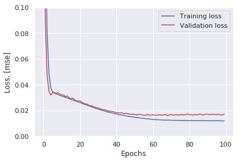

```python
plt.plot(history.history['loss'],
         'b',
         label='Training loss')
plt.plot(history.history['val_loss'],
         'r',
         label='Validation loss')
plt.legend(loc='upper right')
plt.xlabel('Epochs')
plt.ylabel('Loss, [mse]')
plt.ylim([0,.1])
plt.show()
```

## Distribution of loss function in training set:

By plotting the distribution of the loss function in the training set, one can use this to identify a suitable threshold value for identifying an anomaly. In doing this, one can make sure that this threshold is set above the "noise level", and that any flagged anomalies should be statistically significant above the noise background.

```python
X_pred = model.predict(np.array(X_train))
X_pred = pd.DataFrame(X_pred,
                      columns=X_train.columns)
X_pred.index = X_train.index

scored = pd.DataFrame(index=X_train.index)
scored['Loss_mae'] = np.mean(np.abs(X_pred-X_train), axis = 1)
```

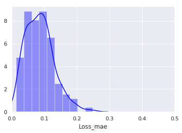

```python
plt.figure()
sns.distplot(scored['Loss_mae'],
             bins = 10,
             kde= True,
            color = 'blue');
plt.xlim([0.0,.5])
plt.savefig('AutoEnc_distr.jpg')
```

If the calculated loss was normal distributed, we could calculate the value 3 standard deviations from the center of the distribution, and use this as the threshold for flagging an anomaly (as done below). However, in this case that resulting threshold value is a bit to low, causing too many "false positives" for flagging anomalies. Due to this, set the trehsold value slightly higher.

```python
threshold = np.mean(scored['Loss_mae']) + 3*np.std(scored['Loss_mae'])
threshold
```

[output not shown]

From the above loss distribution, lets try a threshold of 0.3 for flagging an anomaly. Can then calculate the loss in the test set, to see at which time the output crosses the anomaly threshold.

```python
X_pred = model.predict(np.array(X_test))
X_pred = pd.DataFrame(X_pred,
                      columns=X_test.columns)
X_pred.index = X_test.index

scored = pd.DataFrame(index=X_test.index)
scored['Loss_mae'] = np.mean(np.abs(X_pred-X_test), axis = 1)
scored['Threshold'] = 0.3
scored['Anomaly'] = scored['Loss_mae'] > scored['Threshold']
scored.head()
```

|  | Loss_mae | Threshold | Anomaly |
| --- | --- | --- | --- |
| 2004-02-13 23:52:39 | 0.132962 | 0.3 | False |
| 2004-02-14 00:02:39 | 0.117404 | 0.3 | False |
| 2004-02-14 00:12:39 | 0.034947 | 0.3 | False |
| 2004-02-14 00:22:39 | 0.143995 | 0.3 | False |
| 2004-02-14 00:32:39 | 0.071100 | 0.3 | False |

Calculate same metrics also for training set:

```python
X_pred_train = model.predict(np.array(X_train))
X_pred_train = pd.DataFrame(X_pred_train,
                      columns=X_train.columns)
X_pred_train.index = X_train.index

scored_train = pd.DataFrame(index=X_train.index)
scored_train['Loss_mae'] = np.mean(np.abs(X_pred_train-X_train), axis = 1)
scored_train['Threshold'] = 0.3
scored_train['Anomaly'] = scored_train['Loss_mae'] > scored_train['Threshold']
```

```python
scored = pd.concat([scored_train, scored])
```

## Results from Autoencoder model:

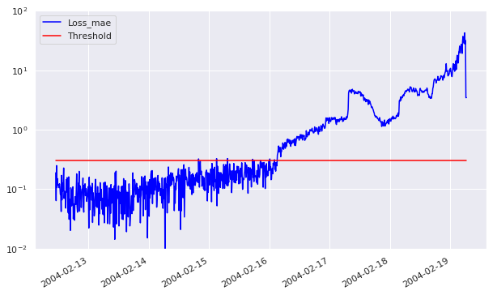

```python
scored.plot(logy=True,  figsize = (10,6), ylim = [1e-2,1e2], color = ['blue','red'])
plt.savefig('Autoencoder.jpg')
```

## Comparing results with PCA model:

We can then compare the output of the Autoencoder model above, and the PCA model below.

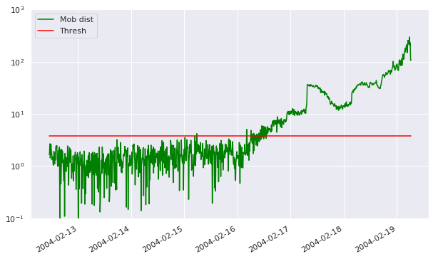

```python
anomaly_alldata.plot(logy=True,figsize = (10,6), ylim = [1e-1,1e3], color = ['green','red'])
plt.savefig('PCA.jpg')
```

# Summary:

Both modeling approaches give similar results, where they are able to flag the upcoming bearing malfunction well in advance of the actual failure. The main difference is essentially how to define a suitable threshold value for flaggig anomalies, to avoid to many false positives during normal operating conditions.